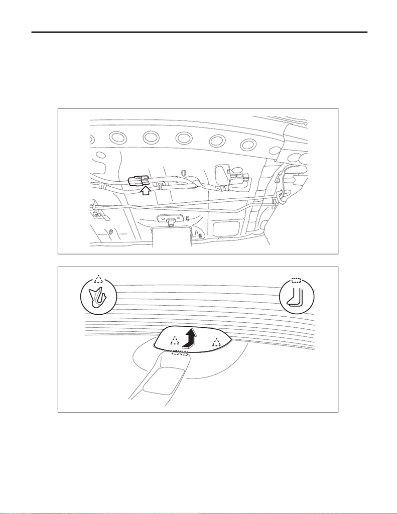

High-mounted Stop Light

LIGHTING SYSTEM

31.High-mounted Stop Light

A: REMOVAL

1) Disconnect the ground cable from battery. <Ref. to NT-5, BATTERY, NOTE, Note.>

NOTE:

For models other than STI model, disconnect the ground terminal from battery sensor.

2) Remove the light assembly - high-mounted.

(1) Disconnect the connector.

(2) Release the claws and hooks, and remove the light assembly - high-mounted.

B: INSTALLATION

1) Install the light assembly - high-mounted.

2) Connect the battery ground terminal. <Ref. to NT-5, BATTERY, NOTE, Note.>

NOTE:

For models other than STI model, connect the ground terminal to battery sensor.

LI-01224

LI-01225

[figure not shown]

High-mounted Stop Light

LIGHTING SYSTEM

C: INSPECTION

1) Apply battery voltage between the connector terminals to check the lighting condition of the light.

2) Replace the light assembly - high-mounted if faulty is found in the inspection.

LI-01728

1 2

Terminal No. Inspection conditions Specification

1 (+) — 2 (–) Apply battery voltage. Light ON